# prj4-1-minimalizace

#### Horní odhady dominantního vlastního čísla diferenciální rovnice s parametrem pomocí obecného polynomu, řešeno symbolicky

Diferenciální rovnice $-u''(t) = \lambda u(t)$

```python
from sympy import *
from IPython.display import display, Markdown, Latex
init_printing()
```

#### Polynom 3. stupně

- $at^3+bt^2+ct+d$
- $d=0$
- $a=1$
- výsledný polynom: $t^3+bt^2-(1+b)t$

```python
a,b,c,t = symbols('a b c t', real=True)
raw_poly = t**3 + b*t**2 - (1+b)*t
raw_poly
```

$$b t^{2} + t^{3} - t \left(b + 1\right)$$

Vyjádření Rayleighova podílu pomocí dosazení obecného polynomu za neznámou funkci.

```python
diff_poly = diff(raw_poly, t)
rq = simplify(integrate(diff_poly**2, (t, 0, 1))/integrate(raw_poly**2, (t, 0, 1)))
rq
```

$$\frac{14 \left(5 b^{2} + 15 b + 12\right)}{7 b^{2} + 21 b + 16}$$

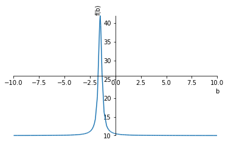

```
<sympy.plotting.plot.Plot at 0x10c95c208>
```

```python
plotting.plot(rq)
```

Najdeme stacionární bod a určíme, zda se jedná o minimum.

```python
diff_rq = simplify(diff(rq, b))
res = solve(diff_rq, b)
```

Jsou stacionární body minima nebo maxima? Určení pomocí dosazení stacionárního bodu do druhé derivace

```python
diff2_rq = simplify(diff(diff_rq, b))
diff2_rq.subs(b,res[0])
```

$$-1792$$

Stacionární bod je maximum, globální minimum je nejspíše v nekonečnu. Je to tak? Zobrazíme graf první derivace.

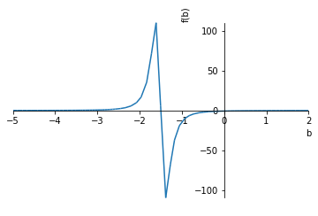

```python
p = plot(diff_rq, (b,-5,2))
```

Pokusíme se najít koeficient takový, aby hodnota první derivace byla ve velmi malém okolí nuly (zprava).

```python
e = Rational(0.0000000001)
res_fin = [N(r) for r in solve(diff_rq - e,b) if N(r) < N(-1.5-e) ]
res_fin
```

$$\left [ -2839.46681555113\right ]$$

Pro tento koeficient pak vyjádříme obecný polynom a vykreslíme jeho graf.

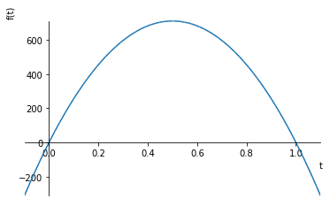

$$t \left(t^{2} - 2839.46681555113 t + 2838.46681555113\right)$$

```python
u_func = raw_poly.subs(b,N(res_fin[0]))
p1 = plot(u_func, (t, -.1, 1.1))
simplify(u_func)
```

Pro všechny hodnoty parametru $b$, které minimalizují Rayleighův podíl, vyjádříme horní odhad dominantního vlastního čísla $\lambda_1$.

```python
import decimal
ctx = decimal.Context()
ctx.prec = 13

rq = integrate(diff(u_func, t)**2, (t,0,1)) / integrate(u_func**2, (t,0,1))

display(Latex('Horní odhad $\lambda_1$: ' + str(rq)))
display(Latex('Řešení úlohy ($\pi^2$): ' + str(N(pi**2))))
display(Latex('Relativní chyba horního odhadu $\lambda_1$: ' + format(ctx.create_decimal(str(100*N((rq-pi**2)/pi**2, 7))), 'f') + '%'))
```

Horní odhad $\lambda_1$: 10.0000001418983

Řešení úlohy ($\pi^2$): 9.86960440108936

Relativní chyba horního odhadu $\lambda_1$: 1.321185%

### Polynom 4. stupně

- $at^4+bt^3+ct^2+dt+e$
- $e=0$
- $a=1$
- výsledný polynom: $t^4+bt^3+ct^2-(1+b+c)t$

```python
b,c,d,t = symbols('b c d t')
raw_poly = t**4 + b*t**3 + c*t**2 - (1+b+c)*t
raw_poly
```

$$b t^{3} + c t^{2} + t^{4} - t \left(b + c + 1\right)$$

Vyjádření Rayleighova podílu pomocí dosazení obecného polynomu za neznámou funkci.

```python
diff_poly = diff(raw_poly, t)
rq = integrate(diff_poly**2, (t, 0, 1)) / integrate(raw_poly**2, (t, 0, 1))
rq
```

$$\frac{\frac{4 b^{2}}{5} + b c + 2 b + \frac{c^{2}}{3} + \frac{6 c}{5} + \frac{9}{7}}{\frac{8 b^{2}}{105} + \frac{b c}{10} + \frac{11 b}{60} + \frac{c^{2}}{30} + \frac{5 c}{42} + \frac{1}{9}}$$

Najdeme stacionární bod a určíme, zda se jedná o minimum.

```python
diff_rq = [simplify(diff(rq, x)) for x in [b,c]]
res = solve(diff_rq,(b,c))

diff2_rq = [[simplify(rq.diff(x).diff(y)) for x in [b,c]] for y in [b,c]]
diff2_rq

sol = []
for i in range(0, len(res)):
    uxx = simplify(diff2_rq[0][0].subs([(b,res[i][0]),(c,res[i][1])]))
    uxy = simplify(diff2_rq[0][1].subs([(b,res[i][0]),(c,res[i][1])]))
    uyy = simplify(diff2_rq[1][1].subs([(b,res[i][0]),(c,res[i][1])]))
    hess = N(uxx*uyy - uxy**2)
    if hess > 0:
        if N(uxx) > 0:
            sol.append(res[i])

sol
```

$$\left [ \left ( -2, \quad - \frac{\sqrt{133}}{21} + \frac{2}{3}\right )\right ]$$

Pro tento koeficient pak vyjádříme obecný polynom a vykreslíme jeho graf.

$$\frac{t \left(21 t^{3} - 42 t^{2} + t \left(- \sqrt{133} + 14\right) + 7 + \sqrt{133}\right)}{21}$$

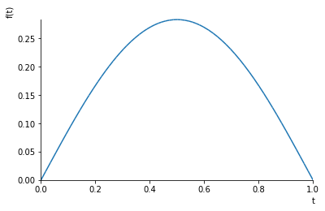

```python
for sol_b, sol_c in sol:
    u_func = simplify(raw_poly.subs([(b,sol_b),(c,sol_c)]))
    display(u_func)
    p1 = plot(u_func, (t, 0, 1))
```

Pro všechny hodnoty parametrů $(b, c)$, které minimalizují Rayleighův podíl, vyjádříme horní odhad dominantního vlastního čísla $\lambda_1$.

```python
rq = integrate(diff(u_func, t)**2, (t,0,1)) / integrate(u_func**2, (t,0,1))

display(Markdown('Horní odhad $\lambda_1$: $'+latex(simplify(rq)) + '$'))
display(Latex('Horní odhad $\lambda_1$ numericky: ' + str(N(rq))))
display(Latex('Řešení úlohy ($\pi^2$): ' + str(N(pi**2))))
display(Latex('Relativní chyba horního odhadu $\lambda_1$: ' + format(ctx.create_decimal(str(100*N((rq-pi**2)/pi**2, 7))), 'f') + '%'))
```

Horní odhad $\lambda_1$: $- 4 \sqrt{133} + 56$

Horní odhad $\lambda_1$ numericky: 9.86974962131682

Řešení úlohy ($\pi^2$): 9.86960440108936

Relativní chyba horního odhadu $\lambda_1$: 0.001471389%